# Replication of Does Seeing Faces of Young Black Boys Facilitate the Identification of Threatening Stimuli? by Todd et al. (2016, Psychological Science)

Kiara Sanchez (klsanch@stanford.edu)

December 16, 2017

## Introduction

Implicit bias and social cognition research demonstrates strong cognitive biases linking Black men to threat, crime, and violence (Correll, et al., 2002; Trawalter et al., 2008; Amodio, 2014; Eberhardt et al., 2004). Through object categorization tasks, the current paper found that these stereotypes extend to Black boys. We attempted to replicate Experiment 3, which used photos of both Black boys and men, and “threatening” and “safe” words. We attempted to replicate the following result:

“Analyses of error-rate data revealed that…there was a significant Race of Prime × Target Word interaction, F(1, 61) = 32.30, p < .001, ηp2 = .35.”

Link to experiment: http://stanford.edu/~klsanch/Todd2016Replication_KS.html

## Methods

### Power Analysis

Original $\sf{η_{p}}$<sup>2</sup> = .35 which translates into an effect size of 0.73 via g*Power software. Power analyses shows that I need 8 participants for 95% power. This effect size is for the 2 (race of prime: Black, White) × 2 (target word: threatening, safe) repeated measures analysis of variance (ANOVA).

### Planned Sample

I proposed a sample of 20 (2.5 times the sample size needed) so we can exclude non-White participants and still anticipate to have at least 8 participants (see power analysis). The original sample consisted of White students, and it is unclear how White participants were recruited. I determined that inclusive recruitment and post hoc exclusion of non-White participants was an approporiate method in order to avoid self-selection bias based on race demographics. For accuracy analyses we only included complete responses (excluded time outs) in order to avoid conflating reaction time and accuracy. See below for other exclusion criteria from original paper:

> “We excluded data from 16 participants with below- chance accuracy on the sequential priming task; retaining their data did not meaningfully alter the results, except that the Race of Prime × Target Word interaction was no longer significant for RTs (p = .116); all other significant effects remained significant (ps < .01). We also excluded data from 2 participants who pressed the same response key on every trial. Computer malfunctions resulted in substantial data loss for 2 additional participants. Together, these exclusions left a final sample of 62 (32 women, 30 men).”

### Materials & Procedure

> “The sequential priming task that we used (adapted from Cesario, Plaks, Hagiwara, Navarrete, & Higgins, 2010) was very similar to that used in Experiment 2b, with these exceptions: First, we replaced the gun and tool images with word stimuli. The participants’ task was to ignore the prime images and instead to rapidly and accurately categorize the words as threatening (violent, dangerous, hostile, aggressive, criminal, and threatening) or safe (innocent, harmless, friendly, trustworthy, peace- ful, and safe). Second, we increased the response deadline to 750 ms. Each of the 24 face primes was paired with each of the 12 target words, which resulted in 288 randomly ordered experimental trials that appeared in a single block of trials. Eight practice trials preceded the experimental trials.”

#### Experiment 1 & 2b procedure:

> “Participants completed a categorization task in which two images flashed on the monitor in quick succession. Participants were instructed to ignore the first image (the prime), which was always a face; it merely signaled that the second image was about to appear. Instead, their pri- mary task was to quickly and accurately categorize the second image (the target object) as a gun or a toy by pressing one of two response keys (key assignments were counterbalanced across participants). The primes were 12 photos of boys (6 Black, 6 White) taken from the Child Affective Facial Expression set (LoBue & Thrasher, 2015). We selected these photos using the following criteria: The faces had to be easily categorized by race, to have a neutral expression, to have no idiosyncrasies (e.g., facial scars), and to be similar in actual age (mean age for Black faces = 4.98 years; mean age for White faces = 5.01 years; p > .250). Each photo was cropped so that it included only the head and was standardized in size. The target objects were 6 gun images taken from Payne (2001) and 6 toy images (e.g., a rattle) taken from online sources. The toy images were con- verted to gray scale and sized to match the gun images. Each trial sequence began with a blank screen (500 ms), followed by a face prime (200 ms), then a tar- get object (200 ms), and finally a pattern mask (which remained on screen until participants responded). If par- ticipants did not respond within 500 ms, a message (“Please respond faster!”) appeared for 1 s. Each of the 12 face primes was paired once with each of the 12 target objects, which resulted in 144 randomly ordered experi- mental trials. Eight practice trials preceded the experimental trials.

> The weapon identification tasks used in Experiments 2a and 2b were very similar to that used Experiment 1, with the following exceptions: First, along with the pho- tos of boys, we included 12 photos of men (6 Black, 6 White) taken from the Chicago Face Database (Ma, Correll, & Wittenbrink, 2015). We selected these photos using criteria similar to those used to select the child photos in Experiment 1. Second, we replaced the toy images with 6 images of tools taken from Payne (2001). Each of the 24 face primes was paired once with each of the 12 target objects, which resulted in 288 randomly ordered experi- mental trials. Sixteen practice trials preceded the experimental trials. In Experiment 2a, the adult and child primes appeared in separate, counterbalanced blocks of trials. In Experiment 2b, the adult and child primes appeared together in a single block of trials."

### Analysis Plan

Key analysis is a 2 (race of prime: White, Black) x 2 (target word: safe, threatening) within-subjects repeated measures ANOVA.

**The key result is a Race of Prime × Target Word interaction: F(1, 61) = 32.30, p < .001, ηp2 = .35.**

See “Planned Sample” section for exclusion criteria.

### Differences from Original Study

The original study sample consisted of White undergraduate college students. We recruited adult participants through MTurk and excluded non-White participants. We do not anticipate significant differences in results based on these criteria.

### Methods Addendum

#### Actual Sample

Twenty mTurk participants completed the study. We excluded 6 participants who indicated that they were from a non-white ethnic group. Nobody’s error rate was above 50%, and no participants reported having computer problems in their survey. Thus, our final sample size was 14.

#### Differences from pre-data collection methods plan

It should be noted that our pre-analysis plan differs from our actual analyses in that we planned to run a 2 (target race) x 2 (word) ANOVA. However, the correct analysis to run for our key result is a 2 (target race) x 2 (word) x 2 (target age) ANOVA. Thus, we ran the power analyses again for the appropriate test, and our needed sample size to obtain 95% power was actually 12, not the proposed 8. This requirement is still appropriate for our obtained sample of 14, so we did not have to re-collect data.

To address the change in analysis, we ran both the preregistered test (2x2) and the corrected analysis. Our results section will reflect the correct analysis (2x2x2).

## Results

### Data preparation

```r
###Data Preparation

####Load Relevant Libraries and Functions
library(tidyverse)
library(rjson)
library(ez)
library(forcats)
#install.packages('TMB')
library(TMB)
library(sjstats)
library(knitr)

####Import data
#NOTE: We are importing pre-processed data here. Raw data from .json files were anonymized in separate R Script and exported as a .csv file. Raw .json files are not in the github folder to protect participants' privacy, but the code we used to anonymize and export as .csv can be found in this github repo (file name: "code_anonymizeData").

d.anonym = read_csv("data_anonymized.csv")

summary(d.anonym)
```

```
##    workerid           religAff            religAtt        ses
##  Length:5760        Length:5760        Min.   :1.0   Min.   :2.00
##  Class :character   Class :character   1st Qu.:1.0   1st Qu.:5.00
##  Mode  :character   Mode  :character   Median :1.0   Median :6.50
##                                        Mean   :1.6   Mean   :5.95
##                                        3rd Qu.:2.0   3rd Qu.:7.25
##                                        Max.   :5.0   Max.   :9.00
##
##       age          comments              Edu          Citizen
##  Min.   :19.00   Length:5760        Min.   :2.00   Min.   :1
##  1st Qu.:28.00   Class :character   1st Qu.:3.00   1st Qu.:1
##  Median :36.00   Mode  :character   Median :3.00   Median :1
##  Mean   :35.94                      Mean   :3.35   Mean   :1
##  3rd Qu.:43.00                      3rd Qu.:4.00   3rd Qu.:1
##  Max.   :58.00                      Max.   :5.00   Max.   :1
##  NA's   :576
##      Gender       Ethnicity      trial_num            rt
##  Min.   :0.00   Min.   :1.00   Min.   :  1.00   Min.   :  0.0
##  1st Qu.:0.00   1st Qu.:1.00   1st Qu.: 72.75   1st Qu.:523.0
##  Median :1.00   Median :1.00   Median :144.50   Median :591.0
##  Mean   :0.55   Mean   :1.95   Mean   :144.50   Mean   :586.6
##  3rd Qu.:1.00   3rd Qu.:3.00   3rd Qu.:216.25   3rd Qu.:678.0
##  Max.   :1.00   Max.   :5.00   Max.   :288.00   Max.   :980.0
##
##     correct         raceStim             word                race
##  Min.   :0.0000   Length:5760        Length:5760        Min.   :  0.00
##  1st Qu.:1.0000   Class :character   Class :character   1st Qu.: 71.75
##  Median :1.0000   Mode  :character   Mode  :character   Median :143.50
##  Mean   :0.8679                                         Mean   :143.50
##  3rd Qu.:1.0000                                         3rd Qu.:215.25
##  Max.   :1.0000                                         Max.   :287.00
##
##    wordStim           responded
##  Length:5760        Min.   :0.0000
##  Class :character   1st Qu.:1.0000
##  Mode  :character   Median :1.0000
##                     Mean   :0.9594
##                     3rd Qu.:1.0000
##                     Max.   :1.0000
##
```

```r
#fix race
d <- d.anonym %>%
  select(-race) %>%
  mutate(targetRace = substr(d.anonym$raceStim,0,1))

#mark NAs
d$rt[d$rt == 0] <- NA

d$word = as.factor(d$word)
d$targetRace = as.factor(d$targetRace)
d$Edu = as.factor(d$Edu)
d$Citizen = as.factor(d$Citizen)
d$Gender = as.factor(d$Gender)
d$Ethnicity = as.factor(d$Ethnicity)
d$raceStim = as.factor(d$raceStim)

###Factoring and re-labeling

d$targetRace = fct_recode(d$targetRace,
                      "Black" = "b",
                        "White" = "w")

d$Gender = fct_recode(d$Gender,
                   "Male" = "1",
                   "Female" = "0")

d$Ethnicity = fct_recode(d$Ethnicity,
                    "Caucasian/White" = "1",
                    "Hispanic/Latino/Latina" = "2",
                    "African American/Black" = "3",
                    "Hispanic/Latino/Latina" = "4",
                    "East Asian" = "5",
                    "Middle Eastern" = "6",
                    "Pacific Islander" = "7",
                    "Native American" = "8",
                    "Mixed" = "9")

# Number of participants
length(unique(d$workerid))
```

```
## [1] 20
```

```r
#### Prepare data for analysis - create columns etc.

#create targetAge variable
  # levels: child, adult
  # 01-06 = child, 07-12 = adult
d = d %>%
  mutate(targetAge = recode(raceStim,
                            "w01" = "child",
                            "w02"= "child",
                            "w03"= "child",
                            "w04"= "child",
                            "w05"= "child",
                            "w06"= "child",
                            "b01"= "child",
                            "b02"= "child",
                            "b03"= "child",
                            "b04"= "child",
                            "b05"= "child",
                            "b06"= "child",
                            "w07"= "adult",
                            "w08"= "adult",
                            "w09"= "adult",
                            "w10"= "adult",
                            "w11"= "adult",
                            "w12"= "adult",
                            "b07"= "adult",
                            "b08"= "adult",
                            "b09"= "adult",
                            "b10"= "adult",
                            "b11"= "adult",
                            "b12"= "adult"))

####Exclusion

#exclude non-white
d <- d %>%
  filter(Ethnicity == "Caucasian/White")

length(unique(d$workerid))
```

```
## [1] 14
```

```r
#participants with higher than 50% error

  #reverse code accuracy in order to calculate % error
     #new variable = 'error', levels: 1 = incorrect, 0 = correct
d$correct = as.factor(d$correct)
d$error= fct_recode(d$correct,
                   "1" = "0",
                   "0" = "1")

d$error = as.character(d$error)
d$error = as.numeric(d$error)

assess_errorRate  <- d %>%
  filter(responded==1) %>%
  group_by(workerid) %>%
  summarise(errorRate = (100*mean(error))) %>%
  filter(errorRate < 50)


#exclude participants with below 50% accuracy
#d = d %>%
 #filter(workerid != "INCLUDE IDs HERE")
#NOT NECESSARY

#exclude responded == 0
d = d %>%
  filter(responded == 1)

unique(d$workerid)
```

```
##  [1] "586e402b" "a2545688" "bd22aedd" "1c84ecf8" "ad35f988" "91137223"
##  [7] "49a8bde"  "5bb3aaf"  "df6adc0e" "260cb9bf" "86c900cd" "98773999"
## [13] "6c4840"   "253321e8"
```

### Confirmatory analysis

```r
# 2 x 2 x 2 anova
aov1 <- ezANOVA(data = d, dv = error, wid = workerid,
               within = .(word, targetRace, targetAge), detailed = T)
#2 x 2 ANOVA
aov2 <- ezANOVA(data = d, dv = error, wid = workerid,
               within = .(word, targetRace), detailed = T)
#calculate eta sq
#part_eta <- SSn/(SSn + SSd)
eta1 = 0.0168379763 / 0.05620882

eta2 = 0.0098498233 / 0.027824162
```

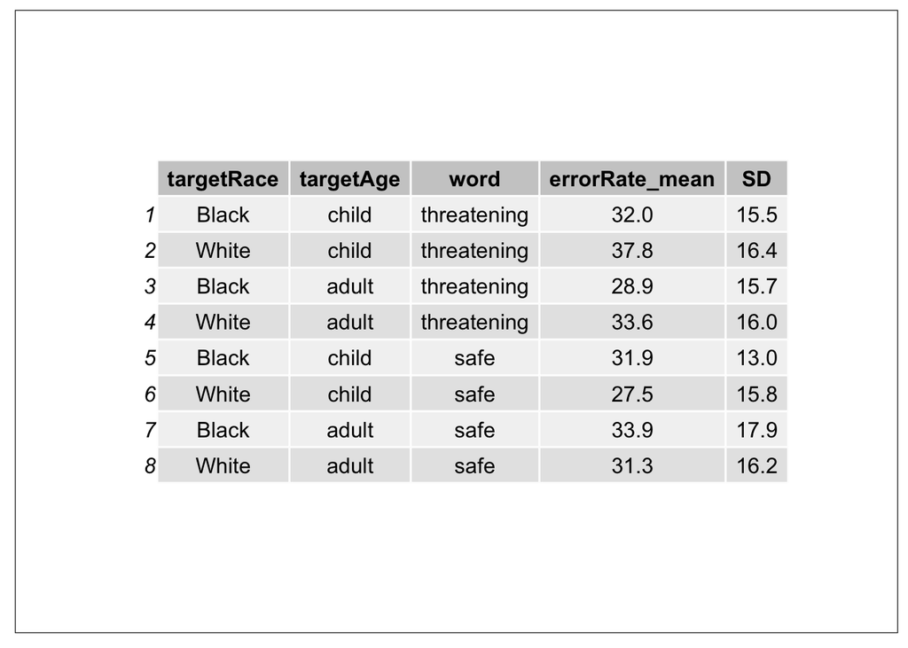

```r
sem <- function(x) {sd(x, na.rm=TRUE) / sqrt(sum(!is.na((x))))} #standard error of the mean
ci <- function(x) {sem(x) * 1.96}

#prepare data for plotting
ds <- d %>%
  group_by(workerid, targetRace, word)  %>%
  summarise(errorRate = 100*mean(error)) %>%
  group_by(targetRace, word) %>%
  summarise(errorRate_mean = mean(errorRate),
            SD = sd(errorRate),
            SE = se(errorRate),
            N = length(errorRate),
            ci = ci(errorRate))


dodge <- position_dodge(width=0.8)
plot1 = ggplot(ds, aes(x = word, y = errorRate_mean)) +
  geom_bar(stat="identity", width = .8, aes(fill=targetRace),position = "dodge") +
  scale_fill_brewer(palette="Greys")  + #change colors of the bars
  scale_y_continuous(limits=c(0,50)) + #this changes the Y axis, make sure to include 0
  theme(axis.text.y = element_text(face="italic",size = rel(1.5),angle=90, hjust=1, vjust=.5)) + #changes y axis text
  theme(axis.title.y=element_text(size=rel(1.5))) + #changes y axis text
  theme_bw()+
  ggtitle("Observed Data") +
  theme(panel.background = element_rect(fill="white",colour="white", size = rel(2)))+theme(panel.grid.major = element_blank(), panel.grid.minor = element_blank(),plot.title = element_text(hjust = 0.5), legend.position = "bottom") +
  labs(y = "Error Rate (%)") +
  geom_errorbar(aes(ymin = errorRate_mean - ci, ymax = errorRate_mean + ci, fill=targetRace), position=dodge, width = 0.1)
dodge <- position_dodge(width=0.8)
plot2 = ggplot(ds, aes(x = targetRace, y = errorRate_mean)) +
  geom_bar(stat="identity", width = .8, aes(fill=word),position = "dodge") +
  scale_fill_brewer(palette="Greys")  + #change colors of the bars
  scale_y_continuous(limits=c(0,50)) + #this changes the Y axis, make sure to include 0
  theme(axis.text.y = element_text(face="italic",size = rel(1.5),angle=90, hjust=1, vjust=.5)) + #changes y axis text
  theme(axis.title.y=element_text(size=rel(1.5))) + #changes y axis text
  theme_bw()+ #gives it a nice clean theme (purely aesthetic)
  ggtitle("Observed Data") +
  theme(panel.background = element_rect(fill="white",colour="white", size = rel(2)))+theme(panel.grid.major = element_blank(), panel.grid.minor = element_blank(), plot.title = element_text(hjust = 0.5), legend.position = "bottom") +
  labs(y = "Error Rate (%)") +
  geom_errorbar(aes(ymin = errorRate_mean - ci, ymax = errorRate_mean + ci, fill=word), position=dodge, width = 0.1)
word = c('threatening', 'threatening', 'threatening', 'threatening', 'safe', 'safe', 'safe', 'safe')
targetRace = c("Black", "White", "Black", "White", "Black", "White", "Black", "White")
targetAge = c("child", "child", "adult", "adult", "child", "child", "adult", "adult")
errorRate_mean = c(32.0, 37.8, 28.9, 33.6, 31.9, 27.5, 33.9, 31.3)
SD = c(15.5, 16.4, 15.7, 16.0, 13.0, 15.8, 17.9, 16.2)

o = data_frame(targetRace, targetAge, word, errorRate_mean, SD)
o$targetRace = as.factor(o$targetRace)

ds.o <- o %>%
  group_by(targetRace, word)  %>%
  summarise(errorRate_mean=mean(errorRate_mean))

#create an empty graph with absolutely nothing :
library(gridExtra)
qplot(1:10, 1:10, geom = "blank") + theme_bw() + theme(line = element_blank(), text = element_blank()) +
# Then I add my table :
annotation_custom(grob = tableGrob(o))
```

```r
dodge <- position_dodge(width=0.8)
plot_o1 = ggplot(o, aes(x = word, y = errorRate_mean)) +
  geom_bar(stat="identity", width = .8, aes(fill=targetRace),position = "dodge") +
  scale_fill_brewer(palette="Greys")  + #change colors of the bars
  scale_y_continuous(limits=c(0,50)) + #this changes the Y axis, make sure to include 0
  theme(axis.text.y = element_text(face="italic",size = rel(1.5),angle=90, hjust=1, vjust=.5)) + #changes y axis text
  theme(axis.title.y=element_text(size=rel(1.5))) + #changes y axis text
    theme_bw()+
  ggtitle("Original Data") +
  theme(panel.background = element_rect(fill="white",colour="white", size = rel(2)))+theme(panel.grid.major = element_blank(), panel.grid.minor = element_blank(), plot.title = element_text(hjust = 0.5), legend.position="bottom") +
  labs(y = "Error Rate (%)")


dodge <- position_dodge(width=0.8)
plot_o2 = ggplot(o, aes(x = targetRace, y = errorRate_mean)) +
  geom_bar(stat="identity", width = .8, aes(fill=word),position = "dodge") +
  scale_fill_brewer(palette="Greys")  + #change colors of the bars
  scale_y_continuous(limits=c(0,50)) + #this changes the Y axis, make sure to include 0
  theme(axis.text.y = element_text(face="italic",size = rel(1.5),angle=90, hjust=1, vjust=.5)) + #changes y axis text
  theme(axis.title.y=element_text(size=rel(1.5))) + #changes y axis text
    theme_bw()+
  theme(panel.background = element_rect(fill="white",colour="white", size = rel(2)))+theme(panel.grid.major = element_blank(), panel.grid.minor = element_blank(),plot.title = element_text(hjust = 0.5), legend.position="bottom") +
  ggtitle("Original Data") +
  labs(y = "Error Rate (%)")
```

```r
library(cowplot)
c1 = plot_grid(plot_o1, plot1, labels = c("1A", "1B"), align = "h")

c2 = plot_grid(plot_o2, plot2, labels = c("2A", "2B"), align = "h")
```

```r
#original data summary
o.ordered <- o[order(targetRace, targetAge, word, decreasing = c(FALSE, TRUE, FALSE), method="radix"),]

library(gridExtra)
table.or = qplot(1:10, 1:10, geom = "blank") + theme_bw() + theme(line = element_blank(), text = element_blank()) +
# Then add my table :
annotation_custom(grob = tableGrob(o.ordered))

#observed data summary
ds_sum <- d %>%
  group_by(workerid, targetRace, targetAge, word)  %>%
  summarise(errorRate = 100*mean(error)) %>%
  group_by(targetRace, targetAge, word) %>%
  summarise(errorRate_mean = mean(errorRate),
            SD = sd(errorRate))


table.ob = qplot(1:10, 1:10, geom = "blank") + theme_bw() + theme(line = element_blank(), text = element_blank()) +
# Then add my table :
annotation_custom(grob = tableGrob(ds_sum))
```

## Discussion

### Summary of Replication Attempt

```r
kable(aov1)
```

| Effect | DFn | DFd | SSn | SSd | F | p | p<.05 | ges |
| --- | --- | --- | --- | --- | --- | --- | --- | --- |
| (Intercept) | 1 | 13 | 1.2861628 | 0.6971675 | 23.9829246 | 0.0002915 | * | 0.5106131 |
| word | 1 | 13 | 0.0355254 | 0.2711846 | 1.7030121 | 0.2145220 |  | 0.0280120 |
| targetRace | 1 | 13 | 0.0005050 | 0.0203500 | 0.3225800 | 0.5797392 |  | 0.0004095 |
| targetAge | 1 | 13 | 0.0053631 | 0.0244920 | 2.8466584 | 0.1153964 |  | 0.0043319 |
| word:targetRace | 1 | 13 | 0.0168380 | 0.0562088 | 3.8942940 | 0.0700951 |  | 0.0134754 |
| word:targetAge | 1 | 13 | 0.0003040 | 0.0819269 | 0.0482322 | 0.8295793 |  | 0.0002465 |
| targetRace:targetAge | 1 | 13 | 0.0028800 | 0.0533262 | 0.7020909 | 0.4172217 |  | 0.0023309 |
| word:targetRace:targetAge | 1 | 13 | 0.0005156 | 0.0280407 | 0.2390491 | 0.6330387 |  | 0.0004181 |

As the original paper did not include a plot, we reconstructed a plot based on the original authors’ means tables and juxtaposed our observed results. Plots and means indicate that our results revealed a trend in the expected direction (See Plots 1A and 1B and Means tables below; error bars on observed plot indicate 95% confidence intervals).

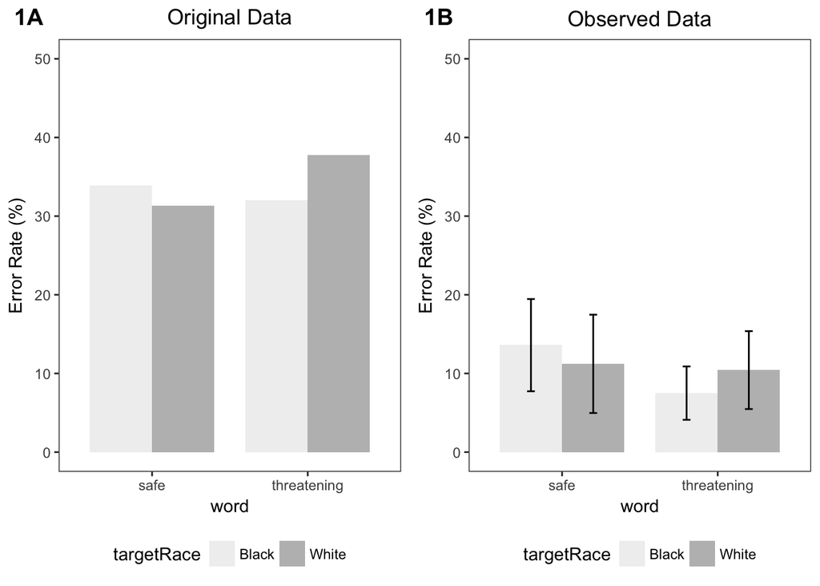

```r
print(c1)
```

##### Original Means Table

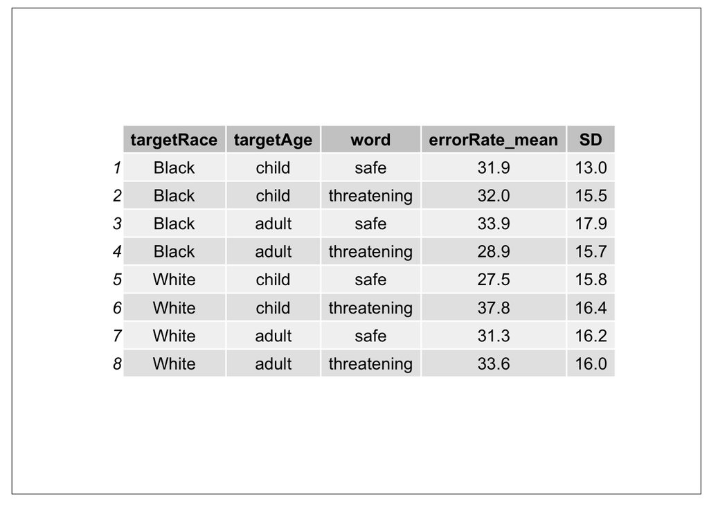

```r
print(table.or)
```

##### Observed Means Table

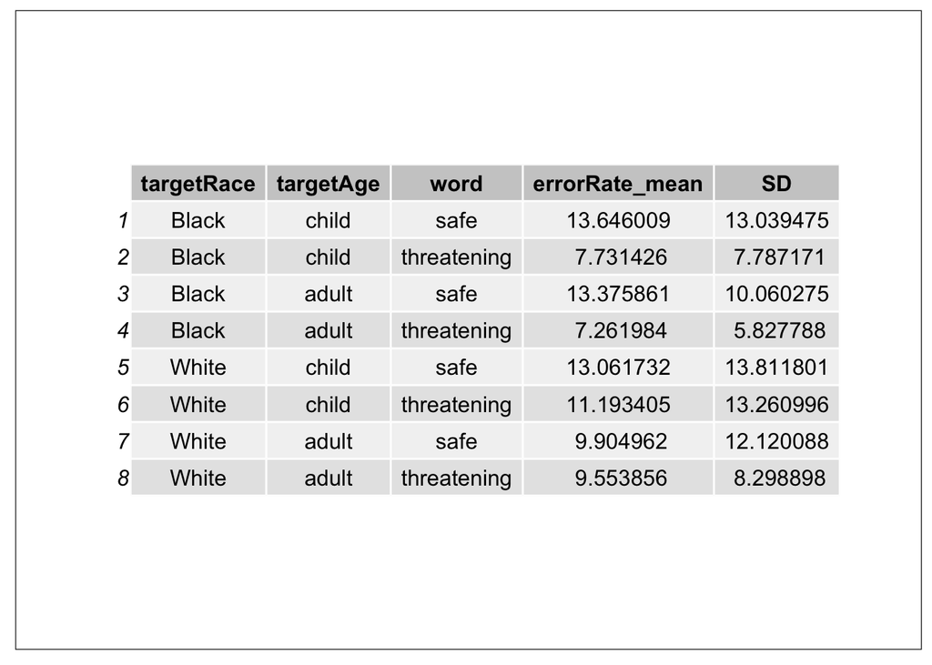

```r
print(table.ob)
```

### Commentary

Overall, this is a marginal or partial replication, leaning more towards a failure. It is likely that the original study was overpowered and thus yielded significant results and a large effect size. Although our data did not reach a significant p-value, it is notable that the results showed a trend in the same direction with such a small sample size.

An interesting observation leads us to ask another question: If the effect of bias on error rate is true, then is a black-threat word or white-safe word bias driving the effect? If we consider the plot below, our data and the original data might tell a different story. In the original study, It appears that the interaction is driven by participants incorrectly labeling threatening words as safe following a White prime (this might indicate a White-safe bias). However, our data show the opposite trend. The marginal interaction appears to be driven by participants incorrectly labeling safe words as threatening following a Black prime (this might indicate a Black-threat bias).

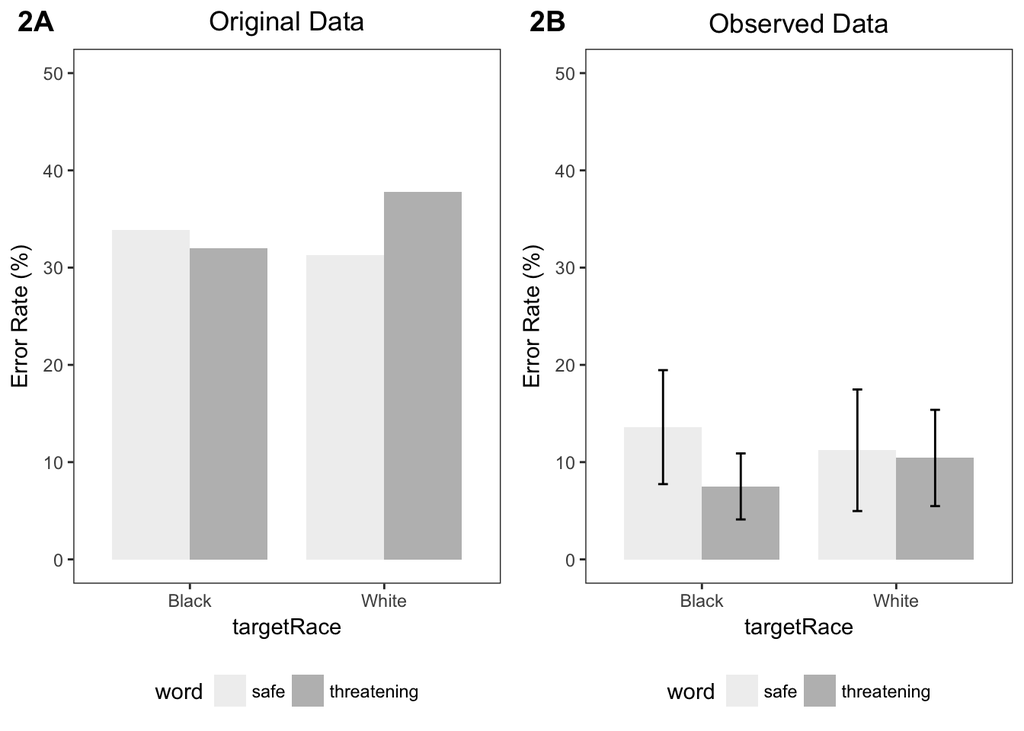

```r
print(c2)
```

I would be interested to further explore what mechanism may be driving differential error rates based on race of prime and words or objects. Even though we did not see our target interaction, the main question of whether cognitive biases linking Black men to threat extends to Black boys is not off the table. We did not see evidence that child primes attenuate any effects. Another replication should be done in the lab, where the original study took place, and perhaps with the original age range (college students).